# Filter_China_only

```r
library(phyloseq)
library(vegan)
```

```r
library(ggplot2)
library(dplyr)
library(tidyverse)
```

the healthy control samples were represented by Chinese individuals, while the T2D samples came from several countries, country could act as a strong confounder. To reduce this bias, we performed a filtered analysis including only samples from China. This allowed us to compare healthy and T2D individuals within the same geographic background and test whether the observed alpha- and beta-diversity differences remained after controlling for country.

```r
load("/Users/natalineschlegel/Desktop/D003924_Diabetes_Mellitus,_T/genus/phyloseq.RData")

pylsq_genus <- pylsq
load("/Users/natalineschlegel/Desktop/D003924_Diabetes_Mellitus,_T/species/phyloseq.RData")
pylsq_species <- pylsq
ls()
```

```
## [1] "pylsq"         "pylsq_genus"   "pylsq_species"
```

```r
# Filter to China only pylsq_species_china
pylsq_species_china <- subset_samples(
  pylsq,
  Country == "China"
)

# Remove empty taxa after filtering
pylsq_species_china <- prune_taxa(
  taxa_sums(pylsq_species_china) > 0,
pylsq_species_china
)

#China genus
pylsq_genus_china <- subset_samples(
  pylsq_genus,
  Country == "China"
)

pylsq_genus_china <- prune_taxa(
  taxa_sums(pylsq_genus_china) > 0,
  pylsq_genus_china
)
```

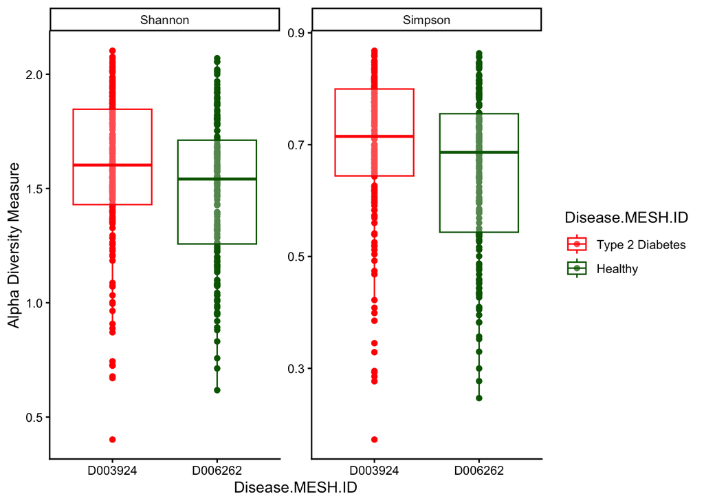

```r
# Alpha diversity plot
plot_richness(
  pylsq_genus_china,
  x = "Disease.MESH.ID",
  measures = c("Shannon", "Simpson"),
  color = "Disease.MESH.ID"
) +
geom_boxplot(alpha = 0.3) +
scale_color_manual(
  values = c("D003924" = "red", "D006262" = "darkgreen"),
  labels = c("Type 2 Diabetes", "Healthy")
) +
theme_classic()
```

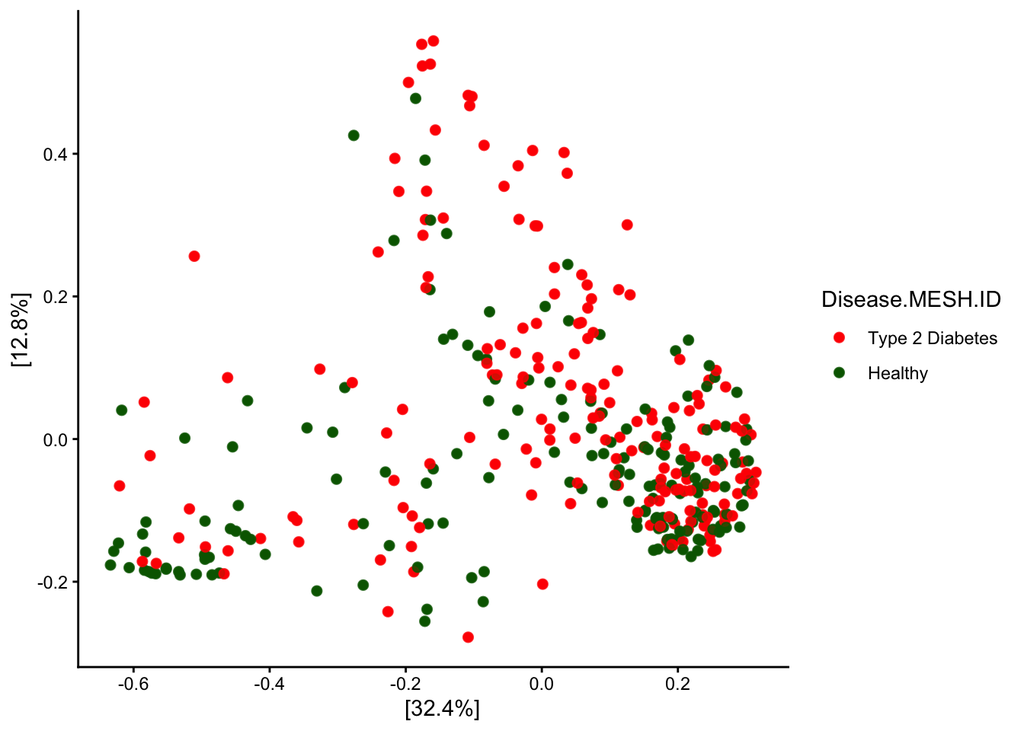

```r
#beta
ord_china <- ordinate(
  pylsq_genus_china,
  method = "PCoA",
  distance = "bray"
)

plot_ordination(
  pylsq_genus_china,
  ord_china,
  type = "samples",
  color = "Disease.MESH.ID"
) +
geom_point(size = 2, alpha = 0.8) +
scale_color_manual(
  values = c("D003924" = "red", "D006262" = "darkgreen"),
  labels = c("Type 2 Diabetes", "Healthy")
) +
theme_classic()
```

```r
#1. Lav en funktion du kan bruge på begge objekter Brug denne kode, men skift pylsq_genus og pylsq_species til de objektnavne, I har efter load().

run_alpha <- function(ps, level_name) {

  otu <- as.data.frame(otu_table(ps))

  if (taxa_are_rows(ps)) {
    otu <- t(otu)
  }

  shannon <- diversity(otu, index = "shannon")
  simpson <- diversity(otu, index = "simpson")

  metadata <- data.frame(sample_data(ps))

  alpha_df <- data.frame(
    SampleID = rownames(otu),
    Shannon = shannon,
    Simpson = simpson,
    Disease = metadata$Disease.MESH.ID,
    Country = metadata$Country,
    Level = level_name
  )

  print(level_name)

  print(
    wilcox.test(
      Shannon ~ Disease,
      data = alpha_df
    )
  )

  print(
    wilcox.test(
      Simpson ~ Disease,
      data = alpha_df
    )
  )

  p <- ggplot(alpha_df, aes(x = Disease, y = Shannon, color = Disease)) +
    geom_boxplot(alpha = 0.3) +
    geom_jitter(width = 0.15, alpha = 0.7) +
    scale_color_manual(
      values = c("D003924" = "red", "D006262" = "blue"),
      labels = c("Type 2 Diabetes", "Healthy")
    ) +
    labs(
      title = paste("Alpha diversity -", level_name),
      x = "Disease status",
      y = "Shannon diversity",
      color = "Disease"
    ) +
    theme_classic()

  print(p)

  return(alpha_df)
}
```

Hvorfor ligner plotsene hinanden? Fordi: • T2D-signalet findes på begge niveauer • sygdommen ændrer ikke kun enkelte arter • men også større bakteriegrupper Det er faktisk biologisk plausibelt.

```r
alpha_genus <- run_alpha(pylsq_genus, "Genus level")
```

```
## [1] "Genus level"
##
##  Wilcoxon rank sum test with continuity correction
##
## data:  Shannon by Disease
## W = 30327, p-value = 3.579e-10
## alternative hypothesis: true location shift is not equal to 0
##
##
##  Wilcoxon rank sum test with continuity correction
##
## data:  Simpson by Disease
## W = 30178, p-value = 7.551e-10
## alternative hypothesis: true location shift is not equal to 0
```

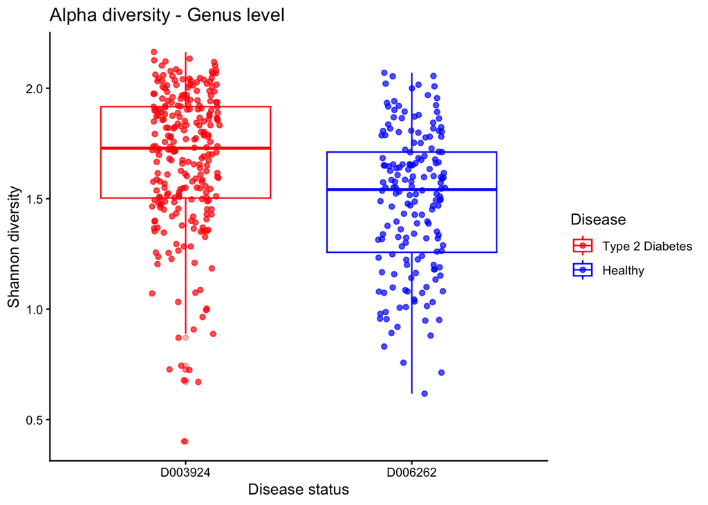

```r
alpha_species <- run_alpha(pylsq_species, "Species level")
```

```
## [1] "Species level"
##
##  Wilcoxon rank sum test with continuity correction
##
## data:  Shannon by Disease
## W = 25348, p-value = 0.01868
## alternative hypothesis: true location shift is not equal to 0
##
##
##  Wilcoxon rank sum test with continuity correction
##
## data:  Simpson by Disease
## W = 25170, p-value = 0.02699
## alternative hypothesis: true location shift is not equal to 0
```

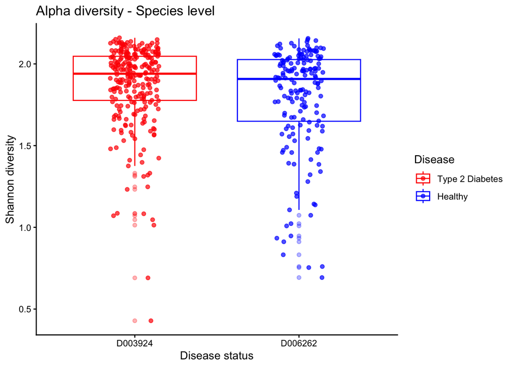

```r
alpha_species_china <- run_alpha(
  pylsq_species_china,
  "Species level - China only")
```

```
## [1] "Species level - China only"
##
##  Wilcoxon rank sum test with continuity correction
##
## data:  Shannon by Disease
## W = 17271, p-value = 0.2263
## alternative hypothesis: true location shift is not equal to 0
##
##
##  Wilcoxon rank sum test with continuity correction
##
## data:  Simpson by Disease
## W = 17129, p-value = 0.2867
## alternative hypothesis: true location shift is not equal to 0
```

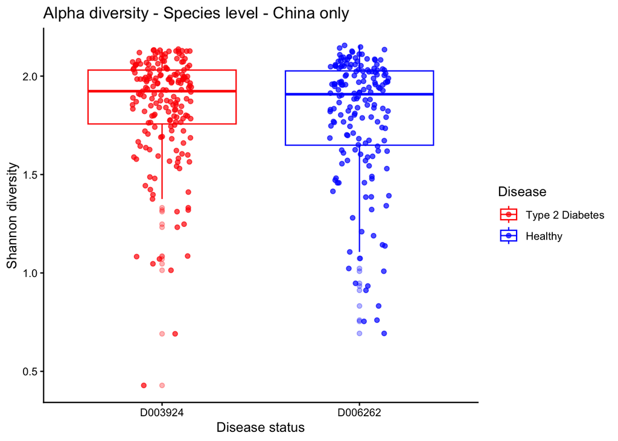

```r
alpha_genus_china <- run_alpha(
  pylsq_genus_china,
  "Genus level - China only"
)
```

```
## [1] "Genus level - China only"
##
##  Wilcoxon rank sum test with continuity correction
##
## data:  Shannon by Disease
## W = 19144, p-value = 0.001829
## alternative hypothesis: true location shift is not equal to 0
##
##
##  Wilcoxon rank sum test with continuity correction
##
## data:  Simpson by Disease
## W = 19103, p-value = 0.002106
## alternative hypothesis: true location shift is not equal to 0
```

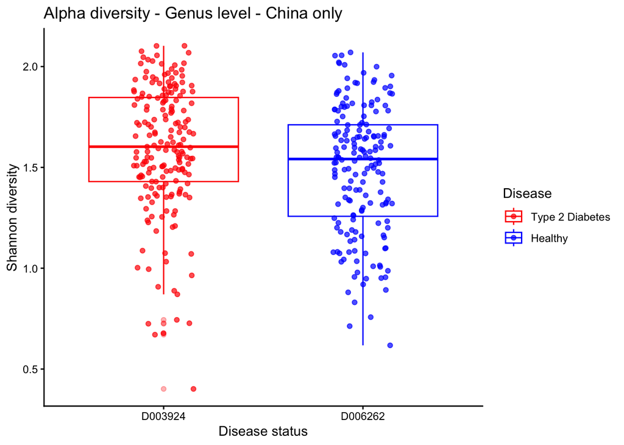

Species-level plottet Ser mere ens ud mellem T2D og Healthy. Det betyder: de har cirka samme samlede antal arter og samme overordnede kompleksitet. Altså: microbiomet er ikke kollapset raske og T2D har stadig mange bakterier Genus-level plottet Her bliver forskellen tydeligere. Det betyder: de store bakteriegrupper fordeler sig anderledes hos diabetikere.

I bør sandsynligvis køre species-level på China-only datasættet først.

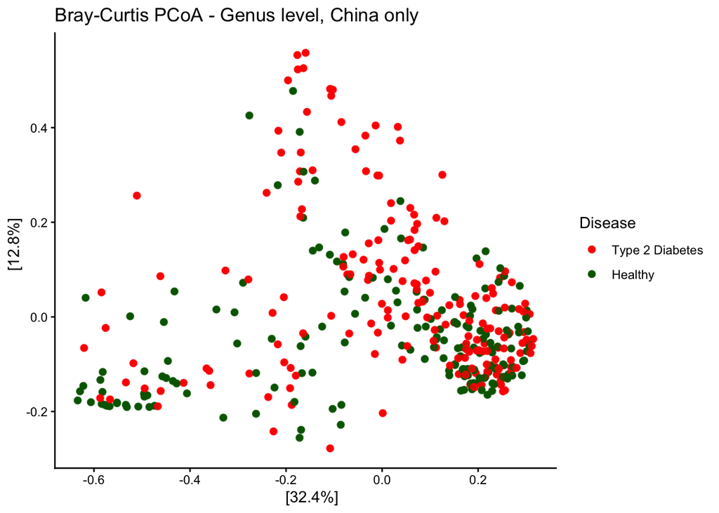

```r
#BETA
# Brug China-only genus objekt
ps <- pylsq_genus_china

# PCoA Bray-Curtis
ord <- ordinate(
  ps,
  method = "PCoA",
  distance = "bray"
)

plot_ordination(
  ps,
  ord,
  type = "samples",
  color = "Disease.MESH.ID"
) +
  geom_point(size = 2, alpha = 0.8) +
  scale_color_manual(
    values = c("D003924" = "red", "D006262" = "darkgreen"),
    labels = c("Type 2 Diabetes", "Healthy")
  ) +
  labs(
    title = "Bray-Curtis PCoA - Genus level, China only",
    color = "Disease"
  ) +
  theme_classic()
```

```r
# NMDS på China-only genus data
```

```r
#2. PERMANOVA på China-only
otu <- as.data.frame(otu_table(pylsq_genus_china))

if (taxa_are_rows(pylsq_genus_china)) {
  otu <- t(otu)
}

metadata <- data.frame(sample_data(pylsq_genus_china))
metadata <- metadata[rownames(otu), ]

bray_dist <- vegdist(otu, method = "bray")

adonis2(
  bray_dist ~ Disease.MESH.ID,
  data = metadata,
  permutations = 999
)
```

```
## Permutation test for adonis under reduced model
## Permutation: free
## Number of permutations: 999
##
## adonis2(formula = bray_dist ~ Disease.MESH.ID, data = metadata, permutations = 999)
##           Df SumOfSqs     R2      F Pr(>F)
## Model      1    1.350 0.0183 6.6536  0.003 **
## Residual 357   72.422 0.9817
## Total    358   73.771 1.0000
## ---
## Signif. codes:  0 '***' 0.001 '**' 0.01 '*' 0.05 '.' 0.1 ' ' 1
```

Der er stadig en statistisk signifikant forskel mellem: kinesiske T2D-patienter kinesiske raske i deres samlede microbiome-sammensætning. Altså: selvom alpha-diversiteten ikke var signifikant på species-niveau, er selve sammensætningen af bakterier stadig forskellig

Alpha diversity Species-level forskellen forsvinder efter China-filter. → T2D giver ikke et generelt kollaps i artsrigdom. Beta diversity PERMANOVA er stadig signifikant. → Sammensætningen af bakterier er stadig forskellig. Altså: T2D-patienter har ikke nødvendigvis færre bakterier, men andre bakterier.

```r
#3. Tjek betadisper

disp <- betadisper(
  bray_dist,
  metadata$Disease.MESH.ID
)

anova(disp)
```

```
## Analysis of Variance Table
##
## Response: Distances
##            Df Sum Sq  Mean Sq F value Pr(>F)
## Groups      1 0.0352 0.035248  1.5142 0.2193
## Residuals 357 8.3104 0.023278
```

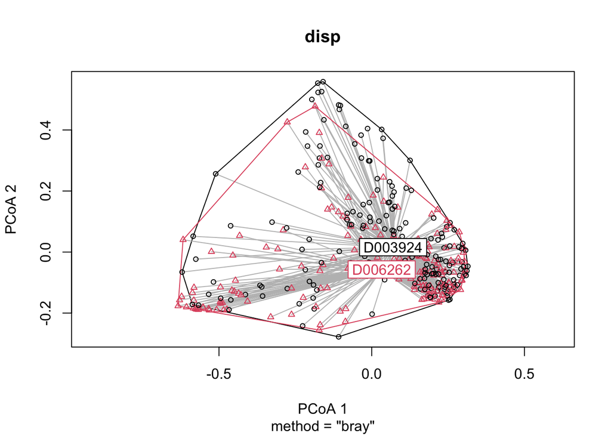

```r
plot(disp)
```

```r
otu_genus <- as.data.frame(otu_table(pylsq_genus_china))

if (taxa_are_rows(pylsq_genus_china)) {
  otu_genus <- t(otu_genus)
}

meta_genus <- data.frame(sample_data(pylsq_genus_china))
meta_genus <- meta_genus[rownames(otu_genus), ]

tax <- data.frame(tax_table(pylsq_genus_china))

results <- data.frame()

for (taxon in colnames(otu_genus)) {

  df <- data.frame(
    abundance = otu_genus[, taxon],
    disease = meta_genus$Disease.MESH.ID
  )

  test <- wilcox.test(abundance ~ disease, data = df)

  mean_T2D <- mean(df$abundance[df$disease == "D003924"], na.rm = TRUE)
  mean_Healthy <- mean(df$abundance[df$disease == "D006262"], na.rm = TRUE)

  results <- rbind(
    results,
    data.frame(
      Taxon = taxon,
      Genus = tax[taxon, "Genus"],
      p_value = test$p.value,
      mean_T2D = mean_T2D,
      mean_Healthy = mean_Healthy,
      direction = ifelse(mean_T2D > mean_Healthy, "Higher in T2D", "Higher in Healthy")
    )
  )
}

results$q_value <- p.adjust(results$p_value, method = "BH")

results_sorted <- results[order(results$q_value), ]

head(results_sorted, 20)
```

```
##      Taxon                  Genus      p_value     mean_T2D mean_Healthy
## 21     841     g__Lachnospiraceae 2.814776e-06 0.0196221246 0.0389660773
## 9     1578    g__Lactobacillaceae 3.542116e-05 0.0115859294 0.0012898593
## 15  216851     g__Ruminococcaceae 7.912028e-05 0.0429367861 0.0657898576
## 6      906     g__Veillonellaceae 1.135802e-04 0.0134776829 0.0020321128
## 53  375288       g__Bacteroidales 9.370297e-04 0.0427409535 0.0265061878
## 29    1678  g__Bifidobacteriaceae 1.520188e-03 0.0408908230 0.0103286901
## 50     838       g__Bacteroidales 2.452032e-03 0.0615801845 0.1371499140
## 55  239934     g__Akkermansiaceae 4.840682e-03 0.0099771791 0.0021211407
## 8      904  g__Acidaminococcaceae 1.027808e-02 0.0033817636 0.0005753750
## 22  207244     g__Lachnospiraceae 1.056801e-02 0.0003877684 0.0000000000
## 44     724         g__Haemophilus 1.639472e-02 0.0014329037 0.0035807570
## 27  100883 g__Erysipelotrichaceae 2.415928e-02 0.0016215465 0.0002625500
## 26    1730      g__Eubacteriaceae 3.342774e-02 0.0534369273 0.0625753372
## 12    1350     g__Enterococcaceae 5.443488e-02 0.0007179513 0.0000000000
```

[output cut: 27 more lines]

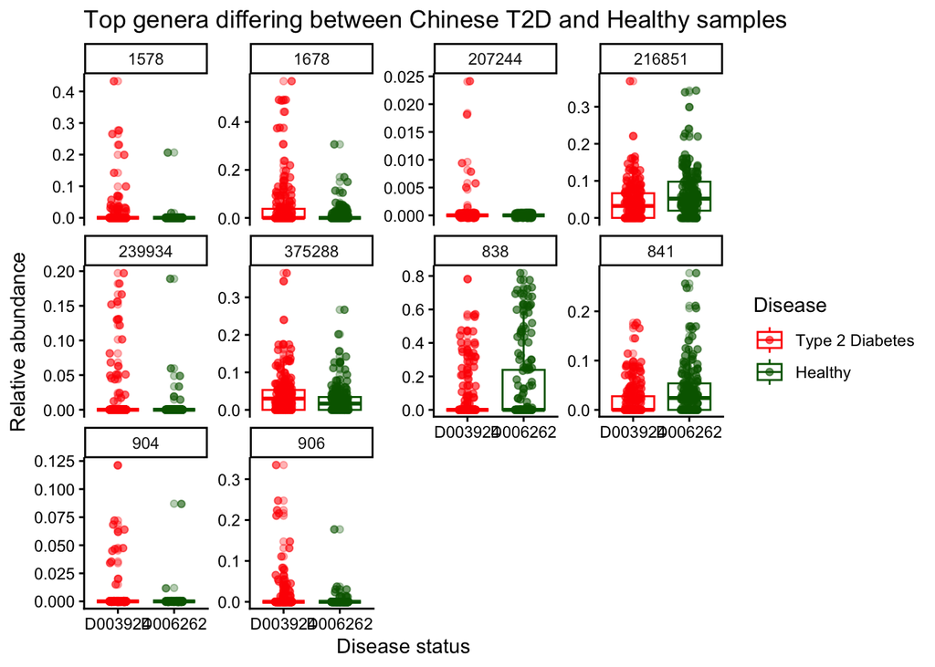

```r
top_taxa <- head(results_sorted$Taxon, 10)

otu_long <- data.frame(
  SampleID = rep(rownames(otu_genus), length(top_taxa)),
  Taxon = rep(top_taxa, each = nrow(otu_genus)),
  Abundance = as.vector(as.matrix(otu_genus[, top_taxa])),
  Disease = rep(meta_genus$Disease.MESH.ID, length(top_taxa))
)

ggplot(otu_long, aes(x = Disease, y = Abundance, color = Disease)) +
  geom_boxplot(alpha = 0.3) +
  geom_jitter(width = 0.15, alpha = 0.6) +
  facet_wrap(~ Taxon, scales = "free_y") +
  scale_color_manual(
    values = c("D003924" = "red", "D006262" = "darkgreen"),
    labels = c("Type 2 Diabetes", "Healthy")
  ) +
  labs(
    title = "Top genera differing between Chinese T2D and Healthy samples",
    x = "Disease status",
    y = "Relative abundance",
    color = "Disease"
  ) +
  theme_classic()
```

1. Differential abundance: Wilcoxon + FDR

```r
# Genus China-only
otu_genus <- as.data.frame(otu_table(pylsq_genus_china))

if (taxa_are_rows(pylsq_genus_china)) {
  otu_genus <- t(otu_genus)
}
meta_genus <- data.frame(sample_data(pylsq_genus_china))
tax <- data.frame(tax_table(pylsq_genus_china))

tax <- data.frame(tax_table(pylsq_genus_china))

results <- data.frame()

for (taxon in colnames(otu_genus)) {

  df <- data.frame(
    abundance = otu_genus[, taxon],
    disease = meta_genus$Disease.MESH.ID
  )

  test <- wilcox.test(abundance ~ disease, data = df)

  mean_T2D <- mean(df$abundance[df$disease == "D003924"], na.rm = TRUE)
  mean_Healthy <- mean(df$abundance[df$disease == "D006262"], na.rm = TRUE)

  results <- rbind(results, data.frame(
    Taxon = taxon,
    Genus = tax[taxon, "Genus"],
    p_value = test$p.value,
    mean_T2D = mean_T2D,
    mean_Healthy = mean_Healthy,
    direction = ifelse(mean_T2D > mean_Healthy, "Higher in T2D", "Higher in Healthy")
  ))
}

results$q_value <- p.adjust(results$p_value, method = "BH")
results_sorted <- results[order(results$q_value), ]

sig_taxa <- subset(results_sorted, q_value < 0.05)
sig_taxa
```

```
##     Taxon                 Genus      p_value    mean_T2D mean_Healthy
## 21    841    g__Lachnospiraceae 2.814776e-06 0.019622125  0.038966077
## 9    1578   g__Lactobacillaceae 3.542116e-05 0.011585929  0.001289859
## 15 216851    g__Ruminococcaceae 7.912028e-05 0.042936786  0.065789858
## 6     906    g__Veillonellaceae 1.135802e-04 0.013477683  0.002032113
## 53 375288      g__Bacteroidales 9.370297e-04 0.042740953  0.026506188
## 29   1678 g__Bifidobacteriaceae 1.520188e-03 0.040890823  0.010328690
## 50    838      g__Bacteroidales 2.452032e-03 0.061580184  0.137149914
## 55 239934    g__Akkermansiaceae 4.840682e-03 0.009977179  0.002121141
##            direction      q_value
## 21 Higher in Healthy 0.0001576275
## 9      Higher in T2D 0.0009917925
## 15 Higher in Healthy 0.0014769119
## 6      Higher in T2D 0.0015901230
## 53     Higher in T2D 0.0104947332
## 29     Higher in T2D 0.0141884237
## 50 Higher in Healthy 0.0196162523
## 55     Higher in T2D 0.0338847734
```

2. CLR + lineær model

```r
library(compositions)
# Lille pseudocount, fordi CLR ikke kan håndtere 0
otu_clr <- clr(otu_genus + 1e-6)
otu_clr <- as.data.frame(otu_clr)

clr_results <- data.frame()

for (taxon in colnames(otu_clr)) {

  df <- data.frame(
    clr_abundance = otu_clr[, taxon],
    Disease = meta_genus$Disease.MESH.ID,
    Sex = meta_genus$Sex,
    BMI = meta_genus$BMI
  )

  model <- lm(clr_abundance ~ Disease, data = df)
  sm <- summary(model)

  pval <- coef(sm)[2, "Pr(>|t|)"]

  clr_results <- rbind(clr_results, data.frame(
    Taxon = taxon,
    Genus = tax[taxon, "Genus"],
    p_value = pval
  ))
}

clr_results$q_value <- p.adjust(clr_results$p_value, method = "BH")
clr_results <- clr_results[order(clr_results$q_value), ]

head(clr_results, 20)
```

```
##     Taxon                  Genus      p_value      q_value
## 21    841     g__Lachnospiraceae 1.704012e-06 9.542468e-05
## 9    1578    g__Lactobacillaceae 3.873058e-05 1.084456e-03
## 6     906     g__Veillonellaceae 1.090554e-04 1.913390e-03
## 15 216851     g__Ruminococcaceae 1.366707e-04 1.913390e-03
## 29   1678  g__Bifidobacteriaceae 4.162077e-03 3.688710e-02
## 50    838       g__Bacteroidales 4.364685e-03 3.688710e-02
## 55 239934     g__Akkermansiaceae 4.610887e-03 3.688710e-02
## 8     904  g__Acidaminococcaceae 1.077649e-02 7.543543e-02
## 22 207244     g__Lachnospiraceae 1.387849e-02 8.287967e-02
## 44    724         g__Haemophilus 1.479994e-02 8.287967e-02
## 26   1730      g__Eubacteriaceae 2.773267e-02 1.294191e-01
## 27 100883 g__Erysipelotrichaceae 2.669580e-02 1.294191e-01
## 19  33042     g__Lachnospiraceae 5.855393e-02 2.206133e-01
## 31 102106   g__Coriobacteriaceae 5.909284e-02 2.206133e-01
## 36    544         g__Citrobacter 5.769189e-02 2.206133e-01
## 53 375288       g__Bacteroidales 6.550739e-02 2.292759e-01
## 12   1350     g__Enterococcaceae 7.468878e-02 2.460336e-01
## 4   29465     g__Veillonellaceae 1.730554e-01 5.383945e-01
## 14   1263     g__Ruminococcaceae 2.375923e-01 5.784855e-01
## 35    846         g__Oxalobacter 2.178041e-01 5.784855e-01
```